# Glycerol and Methanol Fed-Batch Proteomics of Pichia Pastoris

Aiden Beauglehole

February 2025

The proceeding analysis is an analysis of a Pichia Pastoris strain undergoing fed-batch fermentation over 5 different time points. Data collected by N. Huynh.

```r
library(FactoMineR)
library(ggplot2)
library(ggfortify)
library(reshape2)
library(tidyverse)
library(qvalue)
library(limma)
library(dplyr)
library(KEGGREST)
library(clusterProfiler)
library(tidyr)
library(httr)
library(jsonlite)
library(readr)
library(tibble)
library(pathview)
library(purrr)
library(grid)
library(patchwork)
library(VennDiagram)
library(gridExtra)
library(gridGraphics)
library(cowplot)
library(pairwiseAdonis)
library(vegan)
```

# Creates a PCA based on 5th percentile imputation

- Data is obtained from the raw data off Spectronaut. It is partitioned into columns that contain the sample information with rows being the proteins.
- Data then undergoes 5th percentile imputation according to the script below.
- The sample information that defines what each sample represents is provided in a separate csv file called sample_information.
- Data is transposed so the rows and columns are in the right orientation for the PCA to run.

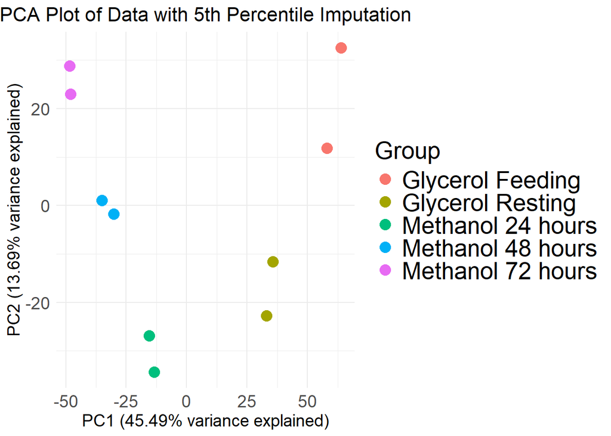

```r
# Load the data
original_data_path <- "data/proteome_data.tsv"
data_original <- read.csv(original_data_path, sep="\t", check.names = FALSE, row.names = 1)
data_original[data_original == "No Data"] <- NA
data_original[] <- lapply(data_original, function(x) as.numeric(as.character(x)))

# Impute missing values using the 5th percentile for each column
percentile_5th <- apply(data_original, 2, function(x) quantile(x, probs = 0.05, na.rm = TRUE))
data_imputed <- data_original
for (i in seq_along(percentile_5th)) {
  data_imputed[is.na(data_imputed[, i]), i] <- percentile_5th[i]
}

# Transpose the data
data_transposed <- as.data.frame(t(data_imputed))

# Perform PCA on the imputed data
pca_imputed <- PCA(data_transposed, scale.unit = TRUE, graph = FALSE)

# Get the percentage of variance explained by PC1 and PC2
pc1_var <- pca_imputed$eig[1, 2]
pc2_var <- pca_imputed$eig[2, 2]

# Create a data frame for the PCA results
pca_df <- data.frame(
  PC1 = pca_imputed$ind$coord[, 1],
  PC2 = pca_imputed$ind$coord[, 2],
  Sample = rownames(pca_imputed$ind$coord)
)

# Load the sample information
sample_info_path <- "data/sample_information.csv"
sample_info <- read.csv(sample_info_path)

# Trim whitespace in the Group column
sample_info$Group <- trimws(sample_info$Group)

# Merge PCA results with sample information
pca_df <- merge(pca_df, sample_info, by = "Sample")

# Plot PCA
ggplot(pca_df, aes(x = PC1, y = PC2, color = Group)) +
  geom_point(size = 4) +
  labs(
    title = "PCA Plot of Data with 5th Percentile Imputation",
    x = paste0("PC1 (", round(pc1_var, 2), "% variance explained)"),
    y = paste0("PC2 (", round(pc2_var, 2), "% variance explained)")
  ) +
  theme_minimal() +
  theme(
    plot.title = element_text(size = 16, hjust = 0.5),
    axis.text = element_text(size = 14),
    axis.title = element_text(size = 14),
    legend.position = "right",
    legend.title = element_text(size = 20),
    legend.text = element_text(size = 20)
  ) +
  scale_fill_discrete(name = "Group") +
  scale_color_discrete(name = "Group")
```

# Histograms showing data distriution of each sample

- Each data sample is trends towards normal distribution with skewing where the 5th percentile imputation occurs

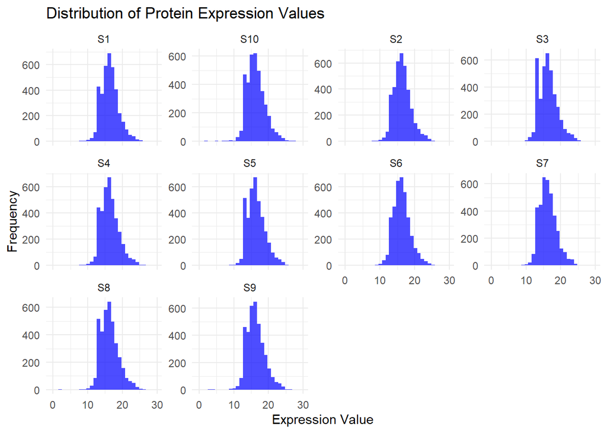

```r
data_long <- data_imputed %>%
    as.data.frame() %>%
    rownames_to_column("Protein") %>%    # Now "Protein" contains the row names
    pivot_longer(cols = -Protein, names_to = "Sample", values_to = "Expression")

# Plot histogram for each sample
ggplot(data_long, aes(x = Expression)) +
    geom_histogram(bins = 30, fill = "blue", alpha = 0.7) +
    facet_wrap(~ Sample, scales = "free_y") +
    labs(title = "Distribution of Protein Expression Values",
         x = "Expression Value",
         y = "Frequency") +
    theme_minimal()
```

# Histogram of the entire data set.

- Distribution analysis continues.
- Checks if the entire data set combined is normally distributed.
- There is skewing at the lower end once again caused by 5th percentile imputation

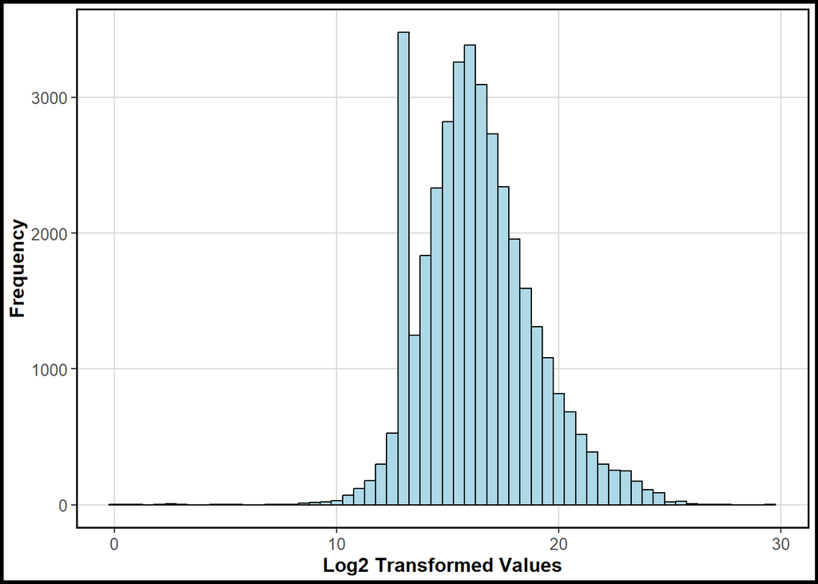

```r
# Combine all the expression values into one vector
all_expression_values <- unlist(data_imputed)

# Convert the combined expression values into a long-format data frame suitable for ggplot2
long_data <- data.frame(
  value = all_expression_values
)

# Plot the histogram using ggplot2
ggplot(long_data, aes(x = value)) +
  geom_histogram(fill = "lightblue", color = "black", binwidth = 0.5) +
  labs(x = "Log2 Transformed Values", y = "Frequency") +
  theme_bw() +
  theme(
    plot.title = element_text(hjust = 0.5, face = "bold", size = 14),
    axis.title.x = element_text(face = "bold", size = 12),
    axis.title.y = element_text(face = "bold", size = 12),
    axis.text.x = element_text(size = 10),
    axis.text.y = element_text(size = 10),
    panel.grid.major = element_line(color = "gray85"),
    panel.grid.minor = element_blank(),
    panel.border = element_rect(colour = "black", fill = NA, size = 1),
    plot.background = element_rect(color = "black", fill = NA, size = 2)
  )
```

# Bar chart showing how each principal component contributes to variation.

- Red line shows a value equal variance = to 11.11%.
- Not necessarily useful in analysing proteomic differences in this sheets current capacity, but useful in for future modeling if required.

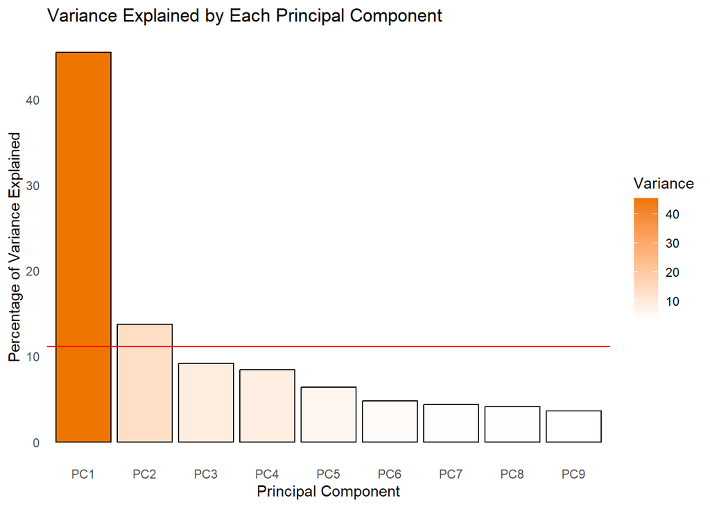

```r
# Extract the proportion of variance explained by each principal component and convert to percentage
explained_var <- pca_imputed$eig[,2]

# Creating the data frame for plotting
explained_var_df <- data.frame(
  PC = factor(paste0("PC", 1:length(explained_var)), levels = paste0("PC", 1:length(explained_var))),
  Variance = explained_var
)

# Plot using ggplot2
ggplot(explained_var_df, aes(x = PC, y = Variance, fill = Variance)) +
  geom_bar(stat = "identity", position = "dodge", color = "black") +
  geom_hline(yintercept = 11.11, col = "red") +
  labs(title = "Variance Explained by Each Principal Component",
       y = "Percentage of Variance Explained", x = "Principal Component") +
  theme_minimal() +
  scale_fill_gradient(low = "white", high = "darkorange2") +
  theme(panel.grid.major = element_blank(),
        panel.grid.minor = element_blank())
```

# Volcano plot showing the significantly different proteins between glycerol feeding and 24 hours of methanol feeding and their log2 fold changes using BH method

# T-tests are performed between the data sets to identify significant differences

- Workflow changes to analysing protein differences between the different time points in the data
- t-tests between log2 fold changes between the datasets are a common way to do this
- The imputed data is used for this analysis
- The Benjamini-Hochberg (BH) method is used for the adjusted p-values

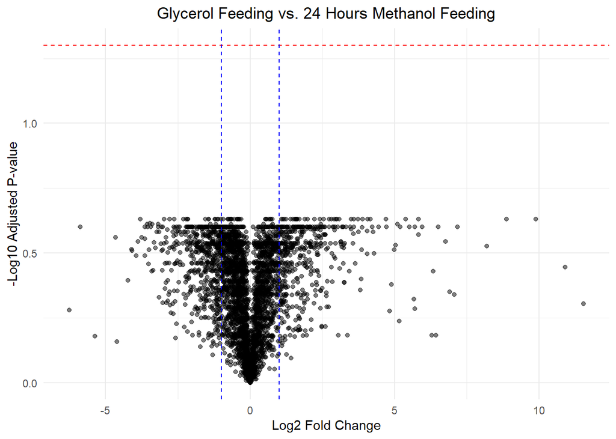

```r
# Define a function to perform the comparison between two groups
compare_groups <- function(group1, group2, sample_info, data_imputed, volcano_title) {
  # Filter the sample information for the two groups of interest
  selected_samples <- sample_info %>%
    filter(Group %in% c(group1, group2))

  # Subset the imputed data to include only the selected samples
  # (Assumes that sample_info$Sample matches the column names of data_imputed)
  data_selected <- data_imputed[, selected_samples$Sample]

  # Split the data into the two groups based on sample_info
  data_group1 <- data_selected[, selected_samples$Sample[selected_samples$Group == group1]]
  data_group2 <- data_selected[, selected_samples$Sample[selected_samples$Group == group2]]

  # Calculate the log2 fold change (group2 minus group1)
  log2_fc <- rowMeans(data_group2, na.rm = TRUE) - rowMeans(data_group1, na.rm = TRUE)

  # Perform t-tests for each protein/row
  p_values <- apply(data_selected, 1, function(x) {
    t.test(x[selected_samples$Group == group2],
           x[selected_samples$Group == group1])$p.value
  })

  # Create a data frame with the results
  results <- data.frame(
    Protein = rownames(data_selected),
    log2FC = log2_fc,
    p_value = p_values,
    stringsAsFactors = FALSE
  )

  # Adjust p-values using the Benjamini–Hochberg method
  results$adj_p_value <- p.adjust(results$p_value, method = "BH")

  # Plot: Histogram of raw p-values
  p1 <- ggplot(results, aes(x = p_value)) +
    geom_histogram(binwidth = 0.01, color = "black", fill = "skyblue") +
    labs(title = paste("Histogram of P-values:", volcano_title),
         x = "P-value",
         y = "Frequency") +
    theme_minimal()

  # Plot: Histogram of adjusted p-values
  p2 <- ggplot(results, aes(x = adj_p_value)) +
    geom_histogram(binwidth = 0.01, color = "black", fill = "skyblue") +
    labs(title = paste("Histogram of Adjusted P-values:", volcano_title),
         x = "Adjusted P-value",
         y = "Frequency") +
    theme_minimal()

  # Plot: Volcano plot
  p3 <- ggplot(results, aes(x = log2FC, y = -log10(adj_p_value))) +
    geom_point(alpha = 0.5) +
    geom_hline(yintercept = -log10(0.05), linetype = "dashed", color = "red") +
    geom_vline(xintercept = c(-1, 1), linetype = "dashed", color = "blue") +
    labs(title = volcano_title,
         x = "Log2 Fold Change",
         y = "-Log10 Adjusted P-value") +
    theme_minimal() +
    theme(plot.title = element_text(hjust = 0.5))

  # Return a list containing the results and the plots
  list(results = results, p1 = p1, p2 = p2, p3 = p3)
}

# Now, call the function for each of your four comparisons:

# 1. Glycerol Feeding vs. Methanol 24 Hours
res_24h <- compare_groups("Glycerol Feeding", "Methanol 24 hours", sample_info, data_imputed,
                          "Glycerol Feeding vs. 24 Hours Methanol Feeding")

# 2. Glycerol Feeding vs. Methanol 48 Hours
res_48h <- compare_groups("Glycerol Feeding", "Methanol 48 hours", sample_info, data_imputed,
                          "Glycerol Feeding vs. 48 Hours Methanol Feeding")

# 3. Glycerol Feeding vs. Methanol 72 Hours
res_72h <- compare_groups("Glycerol Feeding", "Methanol 72 hours", sample_info, data_imputed,
                          "Glycerol Feeding vs. 72 Hours Methanol Feeding")

# 4. Glycerol Feeding vs. Glycerol Resting
res_glycerol_resting <- compare_groups("Glycerol Feeding", "Glycerol Resting", sample_info, data_imputed,
                                       "Glycerol Feeding vs. Glycerol Resting")

# View the volcano plots
print(res_24h$p3)
```

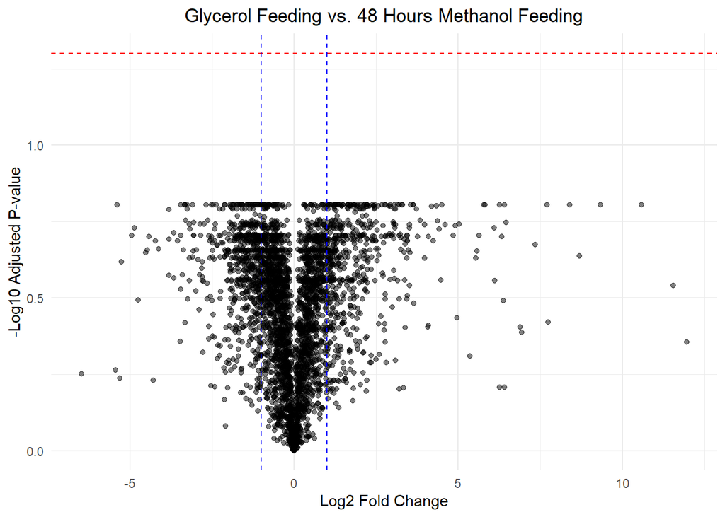

```r
print(res_48h$p3)
```

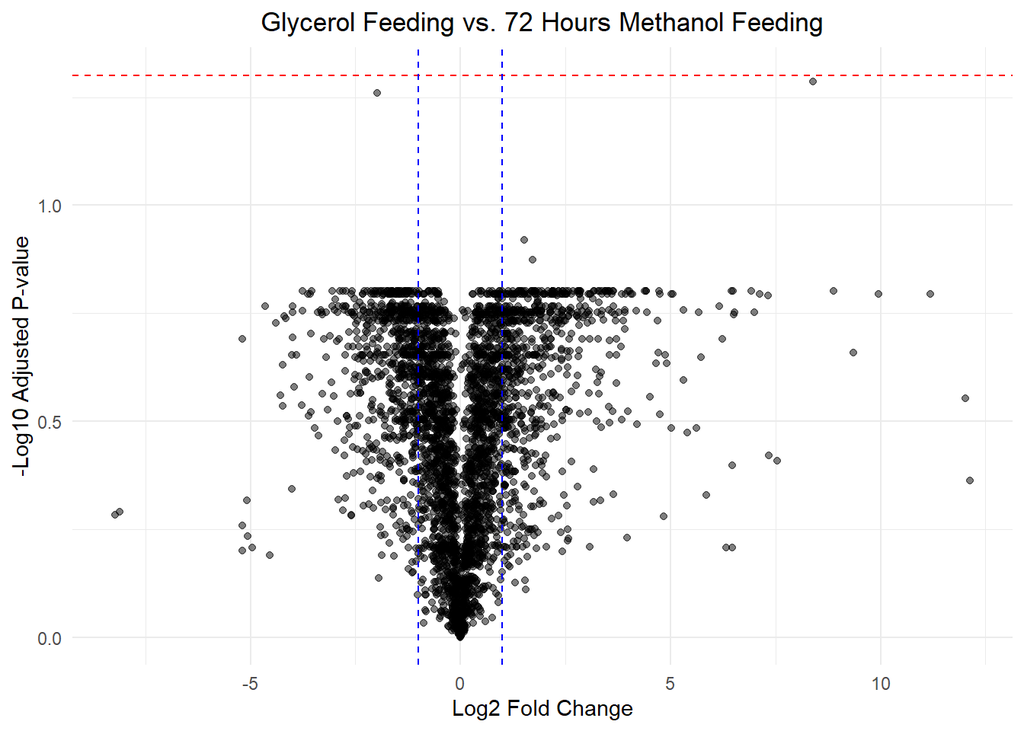

```r
print(res_72h$p3)
```

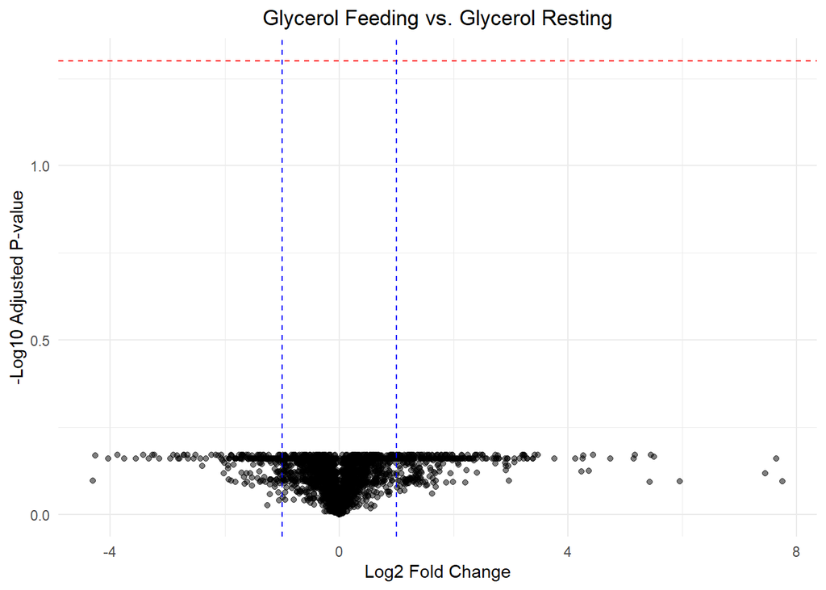

```r
print(res_glycerol_resting$p3)
```

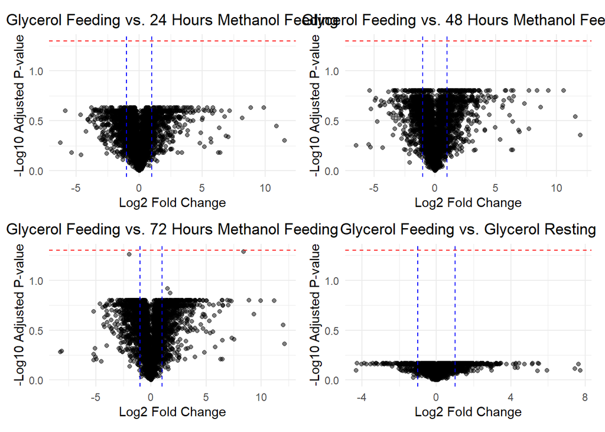

```r
# Combine the volcano plots from the four comparisons into one 2x2 grid
combined_volcano_plot <- (res_24h$p3 | res_48h$p3) / (res_72h$p3 | res_glycerol_resting$p3)

# Display the combined plot
print(combined_volcano_plot)
```

# Volcano plot showing the significantly different proteins between glycerol feeding, glycerol resting, and the subsequent methanol feedings.

- From the volcano plot, no proteins are significantly different in the data set
- As we have low sample numbers between the groups - 2 - it becomes difficult for any significant result to occur due to high variability and low degrees of freedom, which can affect the shape of the t-distribution used to calculate the p-values.
- Empirical Bayes offers an alternative that looks at the entirety of the data set when performing statistics as opposed to the just the proteins of interest within the groups samples.
- Empirical Bayes methods start with Bayesian principles but uses the data itself to estimate the distributional parameters.
- Empirical Bayes methods typically involve “shrinking” estimates towards a central value or towards each other, improving the stability and reliability of the estimates.
- linear models for microarray data- LIMMA - uses Empirical Bayes to estimate the variances and mean differences for each protein. It calculates moderated t-statistics, whic- h are t-statistics that have been adjusted using the EB-estimated variances.
- The moderated t-statistics from this output has ~3.83 degrees of freedom in the context of the moderated t-tests. This is an improvement over the 2 that is provided using just t-test comparisons.

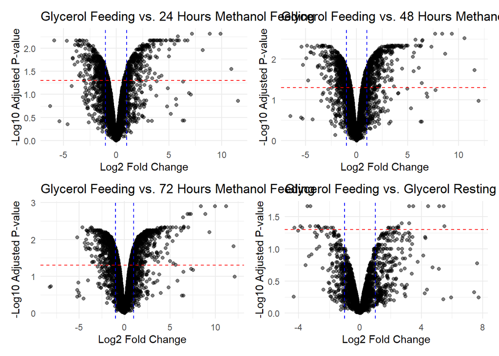

```r
# Define a function to perform empirical Bayes analysis using limma for two groups
compare_groups_limma <- function(group1, group2, sample_info, data_imputed, volcano_title, csv_file_name = NULL) {

  # 1. Filter sample information for the two groups
  selected_samples <- sample_info %>%
    filter(Group %in% c(group1, group2))

  # Subset the imputed data to include only the selected samples
  # (Assumes that sample_info$Sample matches the column names of data_imputed)
  data_selected <- data_imputed[, selected_samples$Sample]

  # 2. Prepare the design matrix (without intercept)
  design <- model.matrix(~ 0 + selected_samples$Group)
  # Set column names based on the groups, replacing spaces with underscores for safe names
  colnames(design) <- c(gsub(" ", "_", group1), gsub(" ", "_", group2))

  # 3. Fit the linear model using limma
  fit <- lmFit(data_selected, design)

  # Create a contrast matrix: group2 - group1
  contrast_formula <- paste0(gsub(" ", "_", group2), " - ", gsub(" ", "_", group1))
  contrast_matrix <- makeContrasts(contrasts = contrast_formula, levels = design)

  # Fit the contrasts and perform empirical Bayes moderation
  fit2 <- contrasts.fit(fit, contrast_matrix)
  fit2 <- eBayes(fit2)

  # 4. Extract the results using topTable (all proteins)
  results <- topTable(fit2, adjust.method = "BH", number = Inf)
  results$Protein <- rownames(results)

  # Extract significantly different proteins: adjusted p-value < 0.05 and |logFC| >= 1
  significant_proteins <- results %>%
    dplyr::filter(adj.P.Val < 0.05 & abs(logFC) >= 1) %>%
    dplyr::select(Protein, logFC, adj.P.Val)

  # If a CSV file name is provided, save the significant proteins list to file
  if (!is.null(csv_file_name)) {
    write.csv(significant_proteins, csv_file_name, row.names = FALSE)
  }

  # 5. Create plots:
  # Histogram of raw p-values
  p_value_histogram <- ggplot(results, aes(x = P.Value)) +
    geom_histogram(binwidth = 0.01, color = "black", fill = "skyblue") +
    labs(title = paste("Histogram of P-values (Empirical Bayes):", volcano_title),
         x = "P-value", y = "Frequency") +
    theme_minimal()

  # Histogram of adjusted p-values
  adj_p_value_histogram <- ggplot(results, aes(x = adj.P.Val)) +
    geom_histogram(binwidth = 0.01, color = "black", fill = "skyblue") +
    labs(title = paste("Histogram of Adjusted P-values (Empirical Bayes):", volcano_title),
         x = "Adjusted P-value", y = "Frequency") +
    theme_minimal()

  # Volcano plot: x = logFC, y = -log10(adj.P.Val)
  volcano_plot <- ggplot(results, aes(x = logFC, y = -log10(adj.P.Val))) +
    geom_point(alpha = 0.5) +
    geom_hline(yintercept = -log10(0.05), linetype = "dashed", color = "red") +
    geom_vline(xintercept = c(-1, 1), linetype = "dashed", color = "blue") +
    labs(title = volcano_title, x = "Log2 Fold Change", y = "-Log10 Adjusted P-value") +
    theme_minimal()

  # Return a list containing the results, significant proteins, and plots
  return(list(results = results,
            significant_proteins = significant_proteins,
            p_value_histogram = p_value_histogram,
            adj_p_value_histogram = adj_p_value_histogram,
            volcano_plot = volcano_plot,
            fit2 = fit2))
}

# Call the function for each of the four comparisons

# 1. Glycerol Feeding vs. Methanol 24 Hours
res_EB_24 <- compare_groups_limma("Glycerol Feeding", "Methanol 24 hours", sample_info, data_imputed,
                                  "Glycerol Feeding vs. 24 Hours Methanol Feeding",
                                  "significant_proteins_glycerol_feeding_methanol_24.csv")

# 2. Glycerol Feeding vs. Methanol 48 Hours
res_EB_48 <- compare_groups_limma("Glycerol Feeding", "Methanol 48 hours", sample_info, data_imputed,
                                  "Glycerol Feeding vs. 48 Hours Methanol Feeding",
                                  "significant_proteins_methanol_48_hours.csv")

# 3. Glycerol Feeding vs. Methanol 72 Hours
res_EB_72 <- compare_groups_limma("Glycerol Feeding", "Methanol 72 hours", sample_info, data_imputed,
                                  "Glycerol Feeding vs. 72 Hours Methanol Feeding",
                                  "significant_proteins_methanol_72_hours.csv")

# 4. Glycerol Feeding vs. Glycerol Resting
res_EB_rest <- compare_groups_limma("Glycerol Feeding", "Glycerol Resting", sample_info, data_imputed,
                                    "Glycerol Feeding vs. Glycerol Resting",
                                    "significant_proteins_glycerol_resting.csv")



# Combine the volcano plots from the four comparisons into one 2×2 grid using patchwork
combined_volcano <- (res_EB_24$volcano_plot | res_EB_48$volcano_plot) /
                    (res_EB_72$volcano_plot | res_EB_rest$volcano_plot)

# Display the combined volcano plot
print(combined_volcano)
```

# Compares the methanol feeding samples between each other

- Uses Empirical Bayes again for t-tests comparing the methanol feeding.

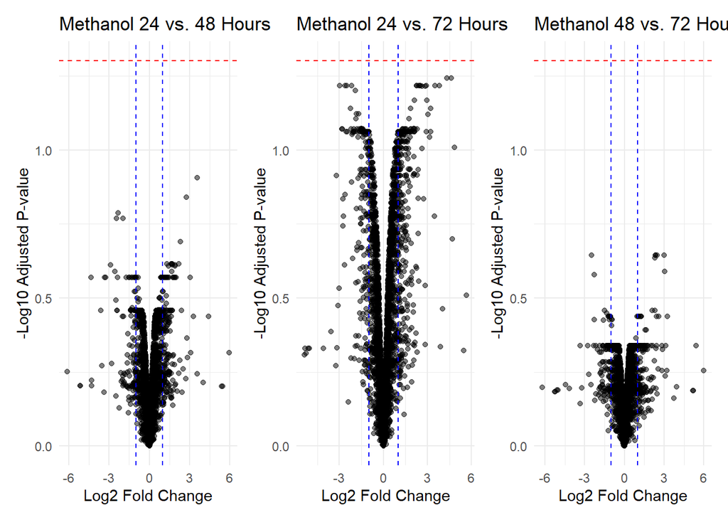

```r
# Compare Methanol 24 hours vs. Methanol 48 hours
res_EB_24_vs_48 <- compare_groups_limma(
  group1 = "Methanol 24 hours",
  group2 = "Methanol 48 hours",
  sample_info = sample_info,
  data_imputed = data_imputed,
  volcano_title = "Methanol 24 vs. 48 Hours",
  csv_file_name = "significant_proteins_methanol_24_vs_48.csv"
)

# Compare Methanol 24 hours vs. Methanol 72 hours
res_EB_24_vs_72 <- compare_groups_limma(
  group1 = "Methanol 24 hours",
  group2 = "Methanol 72 hours",
  sample_info = sample_info,
  data_imputed = data_imputed,
  volcano_title = "Methanol 24 vs. 72 Hours",
  csv_file_name = "significant_proteins_methanol_24_vs_72.csv"
)

# Compare Methanol 48 hours vs. Methanol 72 hours
res_EB_48_vs_72 <- compare_groups_limma(
  group1 = "Methanol 48 hours",
  group2 = "Methanol 72 hours",
  sample_info = sample_info,
  data_imputed = data_imputed,
  volcano_title = "Methanol 48 vs. 72 Hours",
  csv_file_name = "significant_proteins_methanol_48_vs_72.csv"
)

# Combine the volcano plots into one row using patchwork.
# (You can adjust the layout as needed; here we put them side-by-side.)
combined_volcano_methanol <- res_EB_24_vs_48$volcano_plot |
                             res_EB_24_vs_72$volcano_plot |
                             res_EB_48_vs_72$volcano_plot

# Display the combined volcano plot
print(combined_volcano_methanol)
```

# Extraction of annotated pichia proteome to KEGG pathways

```r
# Load the data, this is the entire Pichia proteome
data <- read.csv("data/pichia_proteomics_data_kegg.csv")

# Extract the unique KEGG IDs and remove duplicates
kegg_ids_new <- unique(gsub(";.*", "", data$KEGG))

# Function to fetch pathway annotations for a given KEGG ID
get_pathway_annotations <- function(kegg_id) {
  Sys.sleep(1/2)  # Pause for 1/2 of a second before each request to adhere to the rate limit
  tryCatch({
    pathways <- keggGet(kegg_id)[[1]]$PATHWAY
    if (!is.null(pathways)) {
      return(names(pathways))
    } else {
      return(NA)
    }
  }, error = function(e) {
    message("Error with KEGG ID ", kegg_id, ": ", e$message)
    return(NA)
  })
}

# Split the KEGG IDs into smaller batches if needed
batch_size <- 400  # You can adjust batch size based on your specific needs
kegg_id_batches <- split(kegg_ids_new, ceiling(seq_along(kegg_ids_new)/batch_size))

# Process each batch and collect results
annotations_new <- purrr::map(kegg_id_batches, function(batch) {
  sapply(batch, get_pathway_annotations)
})
```

[output not shown]

[output not shown]

[output not shown]

[output not shown]

[output not shown]

[output not shown]

[output not shown]

[output not shown]

[output not shown]

[output not shown]

[output not shown]

[output not shown]

[output not shown]

[output not shown]

[output not shown]

[output not shown]

[output not shown]

[output not shown]

[output not shown]

[output not shown]

[output not shown]

[output not shown]

[output not shown]

[output not shown]

[output not shown]

[output not shown]

[output not shown]

[output not shown]

[output not shown]

[output not shown]

[output not shown]

[output not shown]

[output not shown]

[output not shown]

[output not shown]

[output not shown]

[output not shown]

[output not shown]

[output not shown]

[output not shown]

[output not shown]

[output not shown]

[output not shown]

[output not shown]

[output not shown]

[output not shown]

[output not shown]

[output not shown]

[output not shown]

[output not shown]

[output not shown]

[output not shown]

[output not shown]

[output not shown]

[output not shown]

[output not shown]

[output not shown]

[output not shown]

[output not shown]

[output not shown]

[output not shown]

[output not shown]

[output not shown]

[output not shown]

[output not shown]

[output not shown]

[output not shown]

[output not shown]

[output not shown]

[output not shown]

[output not shown]

[output not shown]

[output not shown]

[output not shown]

[output not shown]

[output not shown]

[output not shown]

[output not shown]

[output not shown]

[output not shown]

[output not shown]

[output not shown]

[output not shown]

[output not shown]

[output not shown]

[output not shown]

[output not shown]

[output not shown]

[output not shown]

[output not shown]

[output not shown]

[output not shown]

[output not shown]

[output not shown]

[output not shown]

[output not shown]

[output not shown]

[output not shown]

[output not shown]

[output not shown]

[output not shown]

[output not shown]

[output not shown]

[output not shown]

[output not shown]

[output not shown]

[output not shown]

[output not shown]

[output not shown]

[output not shown]

[output not shown]

[output not shown]

[output not shown]

[output not shown]

[output not shown]

[output not shown]

[output not shown]

[output not shown]

[output not shown]

[output not shown]

[output not shown]

[output not shown]

[output not shown]

[output not shown]

[output not shown]

[output not shown]

[output not shown]

[output not shown]

[output not shown]

[output not shown]

[output not shown]

[output not shown]

[output not shown]

```r
# Unlist and simplify the results to match the original structure
annotations_new <- unlist(annotations_new, recursive = FALSE)

# Create a tibble with the results
pathway_annotations_new <- tibble(
  KEGG_ID = names(annotations_new),
  Pathways = I(annotations_new)
)

# Ensure Pathways are wrapped in lists and convert any NULLs or NAs to actual NA values
pathway_annotations_new$Pathways <- lapply(pathway_annotations_new$Pathways, function(x) {
  if (is.null(x) || (is.character(x) && length(x) == 0)) {
    NA
  } else {
    as.list(x)
  }
})

# Use mutate to ensure Pathways is a list and use unnest to convert list elements into separate rows
pathway_annotations_new <- pathway_annotations_new %>%
  mutate(Pathways = purrr::map(Pathways, ~ if (is.null(.x) || length(.x) == 0) NA else .x)) %>%
  unnest(Pathways, keep_empty = TRUE)

# Function to get KEGG pathways
get_kegg_pathways <- function(org_code) {
  url <- paste0("https://rest.kegg.jp/list/pathway/", org_code)
  response <- GET(url)
  content <- content(response, "text")
  pathways <- read.delim(text = content, header = FALSE, sep = "\t", stringsAsFactors = FALSE)

  # Check if the data has the correct format
  if (ncol(pathways) != 2) {
    stop("Unexpected format in KEGG API response")
  }

  colnames(pathways) <- c("PathwayID", "PathwayName")
  return(pathways)
}

# Fetch all Pichia pastoris pathways
pichia_pathways <- get_kegg_pathways("ppa")

# Ensure that both joining columns are of the same type
pathway_annotations_new$Pathways <- as.character(pathway_annotations_new$Pathways)

# Join the pathway annotations with pathway names from Pichia pastoris
matched_pathways_new <- pathway_annotations_new %>%
  left_join(pichia_pathways, by = c("Pathways" = "PathwayID"))

# Save and print the pathway annotations
write.csv(matched_pathways_new, "new_pichia_pathway_annotations.csv", row.names = FALSE)
print(matched_pathways_new)
```

```
## # A tibble: 5,890 × 3
##    KEGG_ID               Pathways PathwayName
##    <chr>                 <chr>    <chr>
##  1 1.ppa:PAS_chr1-3_0025 ppa03440 Homologous recombination - Komagataella phaff…
##  2 1.ppa:PAS_chr1-3_0049 NA       <NA>
##  3 1.ppa:PAS_chr1-3_0091 NA       <NA>
##  4 1.ppa:PAS_chr1-3_0167 NA       <NA>
##  5 1.ppa:PAS_chr1-3_0128 ppa00480 Glutathione metabolism - Komagataella phaffii
##  6 1.ppa:PAS_chr1-3_0128 ppa01100 Metabolic pathways - Komagataella phaffii
##  7 1.ppa:PAS_chr1-3_0149 ppa04011 MAPK signaling pathway - yeast - Komagataella…
##  8 1.ppa:PAS_chr1-3_0301 NA       <NA>
##  9 1.ppa:PAS_chr1-3_0142 ppa03018 RNA degradation - Komagataella phaffii
## 10 1.ppa:PAS_chr1-3_0142 ppa03040 Spliceosome - Komagataella phaffii
## # ℹ 5,880 more rows
```

- The identified proteins from the proteomics study instead of the entire Pichia proteome
- Next, the significantly different proteins comparing the Methanol 24 hours, Methanol 48 hours, and Methanol 72 hours are annotated to the KEGG pathways they are associated with. Glycerol resting is excluded from this portion of the analysis as they have too few pathways associated with their significant proteins.

```r
# Define a helper function for pathway annotation
annotate_pathways <- function(significant_proteins, annotation_fun, output_csv,
                              unnest_method = c("unnest", "unnest_longer")) {
  # Choose the unnest method ("unnest" for 24h; "unnest_longer" for 48h/72h)
  unnest_method <- match.arg(unnest_method)

  # Fetch pathway annotations using the provided annotation function
  annotations <- sapply(significant_proteins$Protein, annotation_fun, USE.NAMES = FALSE)

  # Ensure each element is a list; if NULL or length 0, return NA
  annotations <- lapply(annotations, function(x) {
    if (is.null(x) || length(x) == 0) NA else as.list(x)
  })

  # Create a data frame with the KEGG IDs and the list of pathway annotations
  pathway_annotations <- data.frame(
    KEGG_ID = significant_proteins$Protein,
    Pathways = I(annotations),
    stringsAsFactors = FALSE
  )

  # Make sure the Pathways column is properly treated as a list-column
  pathway_annotations$Pathways <- lapply(pathway_annotations$Pathways, function(x) {
    if (length(x) == 1 && is.na(x)) NA else x
  })

  # Expand the pathways data using the specified unnesting method
  if (unnest_method == "unnest") {
    pathway_annotations <- pathway_annotations %>% unnest(Pathways, keep_empty = TRUE)
  } else {  # "unnest_longer"
    pathway_annotations <- pathway_annotations %>% tidyr::unnest_longer(col = Pathways)
  }

  # Convert the Pathways column to character type
  pathway_annotations$Pathways <- as.character(pathway_annotations$Pathways)

  # Join the pathway annotations with pathway names from pichia_pathways
  matched_pathways <- pathway_annotations %>%
    left_join(pichia_pathways, by = c("Pathways" = "PathwayID"))

  # Save the results to a CSV file
  write.csv(matched_pathways, output_csv, row.names = FALSE)

  # Print and return the matched pathways data frame
  print(matched_pathways)
  return(matched_pathways)
}

### Process Methanol 24 Hours ###
# (Assumes significant_proteins_24 and get_pathway_annotations are available.)
significant_proteins_24 <- read.csv("significant_proteins_glycerol_feeding_methanol_24.csv", stringsAsFactors = FALSE)
matched_pathways_24 <- annotate_pathways(
  significant_proteins = significant_proteins_24,
  annotation_fun = get_pathway_annotations,
  output_csv = "pichia_pathway_annotations_24.csv",
  unnest_method = "unnest"  # as in your original 24h script
)
```

[output not shown]

[output not shown]

[output not shown]

[output not shown]

[output not shown]

[output not shown]

[output not shown]

[output not shown]

[output not shown]

[output not shown]

[output not shown]

[output not shown]

[output not shown]

[output not shown]

[output not shown]

[output not shown]

[output not shown]

[output not shown]

[output not shown]

[output not shown]

[output not shown]

[output not shown]

[output not shown]

[output not shown]

[output not shown]

[output not shown]

[output not shown]

[output not shown]

[output not shown]

```
## # A tibble: 1,051 × 3
##    KEGG_ID             Pathways PathwayName
##    <chr>               <chr>    <chr>
##  1 ppa:PAS_chr1-4_0699 NULL     <NA>
##  2 F2QWE8              NULL     <NA>
##  3 ppa:PAS_chr3_1071   NULL     <NA>
##  4 ppa:PAS_chr3_1028   ppa00010 Glycolysis / Gluconeogenesis - Komagataella pha…
##  5 ppa:PAS_chr3_1028   ppa00071 Fatty acid degradation - Komagataella phaffii
##  6 ppa:PAS_chr3_1028   ppa00350 Tyrosine metabolism - Komagataella phaffii
##  7 ppa:PAS_chr3_1028   ppa00620 Pyruvate metabolism - Komagataella phaffii
##  8 ppa:PAS_chr3_1028   ppa00680 Methane metabolism - Komagataella phaffii
##  9 ppa:PAS_chr3_1028   ppa01100 Metabolic pathways - Komagataella phaffii
## 10 ppa:PAS_chr3_1028   ppa01110 Biosynthesis of secondary metabolites - Komagat…
## # ℹ 1,041 more rows
```

```r
### Process Methanol 48 Hours ###
# Read in the significant proteins file if not already loaded:
significant_proteins_48 <- read.csv("significant_proteins_methanol_48_hours.csv", stringsAsFactors = FALSE)
matched_pathways_48 <- annotate_pathways(
  significant_proteins = significant_proteins_48,
  annotation_fun = get_pathway_annotations,
  output_csv = "pichia_pathway_annotations_48.csv",
  unnest_method = "unnest_longer"
)
```

[output not shown]

[output not shown]

[output not shown]

[output not shown]

[output not shown]

[output not shown]

[output not shown]

[output not shown]

[output not shown]

[output not shown]

[output not shown]

[output not shown]

[output not shown]

[output not shown]

[output not shown]

[output not shown]

[output not shown]

[output not shown]

[output not shown]

[output not shown]

[output not shown]

[output not shown]

[output not shown]

[output not shown]

[output not shown]

[output not shown]

[output not shown]

[output not shown]

[output not shown]

[output not shown]

[output not shown]

[output not shown]

[output not shown]

[output not shown]

[output not shown]

[output not shown]

[output not shown]

[output not shown]

[output not shown]

[output not shown]

[output not shown]

[output not shown]

```
## # A tibble: 1,444 × 3
##    KEGG_ID             Pathways PathwayName
##    <chr>               <chr>    <chr>
##  1 ppa:PAS_chr1-4_0699 <NA>     <NA>
##  2 A0A1G4KQU5          <NA>     <NA>
##  3 F2QWE8              <NA>     <NA>
##  4 ppa:PAS_chr3_1071   <NA>     <NA>
##  5 ppa:PAS_chr4_0303   <NA>     <NA>
##  6 ppa:PAS_chr4_0844   ppa04141 Protein processing in endoplasmic reticulum - K…
##  7 ppa:PAS_chr3_1028   ppa00010 Glycolysis / Gluconeogenesis - Komagataella pha…
##  8 ppa:PAS_chr3_1028   ppa00071 Fatty acid degradation - Komagataella phaffii
##  9 ppa:PAS_chr3_1028   ppa00350 Tyrosine metabolism - Komagataella phaffii
## 10 ppa:PAS_chr3_1028   ppa00620 Pyruvate metabolism - Komagataella phaffii
## # ℹ 1,434 more rows
```

```r
### Process Methanol 72 Hours ###
# Read in the significant proteins file if not already loaded:
significant_proteins_72 <- read.csv("significant_proteins_methanol_72_hours.csv", stringsAsFactors = FALSE)
matched_pathways_72 <- annotate_pathways(
  significant_proteins = significant_proteins_72,
  annotation_fun = get_pathway_annotations,
  output_csv = "pichia_pathway_annotations_72.csv",
  unnest_method = "unnest_longer"
)
```

[output not shown]

[output not shown]

[output not shown]

[output not shown]

[output not shown]

[output not shown]

[output not shown]

[output not shown]

[output not shown]

[output not shown]

[output not shown]

[output not shown]

[output not shown]

[output not shown]

[output not shown]

[output not shown]

[output not shown]

[output not shown]

[output not shown]

[output not shown]

[output not shown]

[output not shown]

[output not shown]

[output not shown]

[output not shown]

[output not shown]

[output not shown]

[output not shown]

[output not shown]

[output not shown]

[output not shown]

[output not shown]

[output not shown]

[output not shown]

[output not shown]

[output not shown]

[output not shown]

[output not shown]

[output not shown]

[output not shown]

[output not shown]

[output not shown]

```
## # A tibble: 1,761 × 3
##    KEGG_ID             Pathways PathwayName
##    <chr>               <chr>    <chr>
##  1 ppa:PAS_chr3_1071   <NA>     <NA>
##  2 F2QWE8              <NA>     <NA>
##  3 ppa:PAS_chr1-4_0699 <NA>     <NA>
##  4 ppa:PAS_chr3_1028   ppa00010 Glycolysis / Gluconeogenesis - Komagataella pha…
##  5 ppa:PAS_chr3_1028   ppa00071 Fatty acid degradation - Komagataella phaffii
##  6 ppa:PAS_chr3_1028   ppa00350 Tyrosine metabolism - Komagataella phaffii
##  7 ppa:PAS_chr3_1028   ppa00620 Pyruvate metabolism - Komagataella phaffii
##  8 ppa:PAS_chr3_1028   ppa00680 Methane metabolism - Komagataella phaffii
##  9 ppa:PAS_chr3_1028   ppa01100 Metabolic pathways - Komagataella phaffii
## 10 ppa:PAS_chr3_1028   ppa01110 Biosynthesis of secondary metabolites - Komagat…
## # ℹ 1,751 more rows
```

# Hypergeometric test

- Next, the pathways that are identified undergo pathway enrichment.
- Pathways that are statistically over represented among differentially expressed proteins are identified using pathway enrichment analysis.
- This involves a hypergeometric test, which calculates the probability of observing as many or more differentially expressed proteins in each pathway as occurs in the actual data, under the assumption that proteins are distributed across pathways randomly. Here,

$$p(k,M,n,N) = \frac{\binom{n}{k}
\binom{M-n}{N-k}}{\binom{M}{N}}$$

- k is the number of differentially expressed proteins in a specific pathway,
- N is the total number of proteins annotated to that pathway in the genome,
- n is the total number of differentially expressed proteins detected, and
- M is the total number of proteins annotated to any pathway.
- A Benjamini-Hochberg correction is then applied to adjust p-values for multiple testing.

```r
# Define the enrichment function
perform_enrichment <- function(significant_csv, background_csv, output_csv) {

  # Load background data and significant data
  background_data <- read.csv(background_csv, stringsAsFactors = FALSE)
  significant_data <- read.csv(significant_csv, stringsAsFactors = FALSE)

  # Filter out rows where Pathways is NA or "NULL"
  background_data_filtered <- background_data %>%
    filter(!is.na(Pathways) & Pathways != "NULL")

  significant_data_filtered <- significant_data %>%
    filter(!is.na(Pathways) & Pathways != "NULL")

  # Count occurrences of each pathway in the background data
  background_counts <- background_data_filtered %>%
    group_by(Pathways) %>%
    summarise(Count = n(), .groups = "drop")

  # Count occurrences in the significant data
  significant_counts <- significant_data_filtered %>%
    group_by(Pathways) %>%
    summarise(Count = n(), .groups = "drop")

  # Merge counts by pathway (using suffixes to distinguish)
  enrichment_data <- left_join(significant_counts, background_counts, by = "Pathways",
                               suffix = c(".significant", ".background"))

  # Replace any NA counts with zero
  enrichment_data <- enrichment_data %>%
    mutate(
      Count.significant = ifelse(is.na(Count.significant), 0, Count.significant),
      Count.background = ifelse(is.na(Count.background), 0, Count.background)
    )

  # Calculate total numbers:
  # M: total number of proteins with pathway annotation in the background
  # n: total number of significant proteins with pathway annotation
  M <- sum(background_counts$Count)
  n <- sum(significant_counts$Count)

  # Perform the hypergeometric test for each pathway.
  # For each pathway, k = Count.significant and N = Count.background.
  enrichment_data <- enrichment_data %>%
    mutate(
      p_value = mapply(function(k, N) {
        phyper(k - 1, N, M - N, n, lower.tail = FALSE)
      }, k = Count.significant, N = Count.background)
    )

  # Adjust p-values using the Benjamini-Hochberg method
  enrichment_data$p_adjust <- p.adjust(enrichment_data$p_value, method = "BH")

  # Filter for significant pathways (adjusted p-value < 0.05)
  significant_pathways <- enrichment_data %>% filter(p_adjust < 0.05)

  # Save the enrichment results to a CSV file
  write.csv(significant_pathways, output_csv, row.names = FALSE)

  # Print and return the significant enrichment results
  print(significant_pathways)
  return(significant_pathways)
}

### Define the background file path (adjust the path as needed) ###
background_file_path <- "data/proteome_background_pathway_annotations.csv"

### Now, call the function for each condition ###

# Enrichment for Methanol 24 Hours
enrichment_results_24 <- perform_enrichment(
  significant_csv = "pichia_pathway_annotations_24.csv",
  background_csv = background_file_path,
  output_csv = "pathway_enrichment_results_24.csv"
)
```

```
## # A tibble: 7 × 5
##   Pathways Count.significant Count.background       p_value    p_adjust
##   <chr>                <int>            <dbl>         <dbl>       <dbl>
## 1 ppa00071                 8               12 0.000158      0.00438
## 2 ppa00100                 8               15 0.00128       0.0284
## 3 ppa00410                 8               16 0.00219       0.0370
## 4 ppa01100               124              592 0.00234       0.0370
## 5 ppa03460                 3                0 0             0
## 6 ppa04081                 1                0 0             0
## 7 ppa04146                22               38 0.00000000959 0.000000355
```

```r
# Enrichment for Methanol 48 Hours
enrichment_results_48 <- perform_enrichment(
  significant_csv = "pichia_pathway_annotations_48.csv",
  background_csv = background_file_path,
  output_csv = "pathway_enrichment_results_48.csv"
)
```

```
## # A tibble: 12 × 5
##    Pathways Count.significant Count.background   p_value p_adjust
##    <chr>                <int>            <dbl>     <dbl>    <dbl>
##  1 ppa00051                11               21 0.00256   0.0320
##  2 ppa00410                 9               16 0.00340   0.0367
##  3 ppa00541                 1                0 0         0
##  4 ppa00620                15               34 0.00393   0.0390
##  5 ppa00710                10               17 0.00126   0.0188
##  6 ppa01100               166              592 0.000321  0.00546
##  7 ppa01110                79              266 0.00269   0.0320
##  8 ppa01320                 4                0 0         0
##  9 ppa03460                 1                0 0         0
## 10 ppa04081                 1                0 0         0
## 11 ppa04142                 1                0 0         0
## 12 ppa04146                20               38 0.0000439 0.000870
```

```r
# Enrichment for Methanol 72 Hours
enrichment_results_72 <- perform_enrichment(
  significant_csv = "pichia_pathway_annotations_72.csv",
  background_csv = background_file_path,
  output_csv = "pathway_enrichment_results_72.csv"
)
```

```
## # A tibble: 12 × 5
##    Pathways Count.significant Count.background   p_value p_adjust
##    <chr>                <int>            <dbl>     <dbl>    <dbl>
##  1 ppa00250                16               26 0.000421  0.00598
##  2 ppa00541                 1                0 0         0
##  3 ppa00650                 8               11 0.00291   0.0311
##  4 ppa00710                12               17 0.000368  0.00589
##  5 ppa01100               202              592 0.000609  0.00779
##  6 ppa01110               105              266 0.0000385 0.000704
##  7 ppa01320                 6                0 0         0
##  8 ppa03460                 3                0 0         0
##  9 ppa04081                 1                0 0         0
## 10 ppa04142                 3                0 0         0
## 11 ppa04146                20               38 0.00137   0.0159
## 12 ppa05100                 1                0 0         0
```

# Venn digram of methanol expression

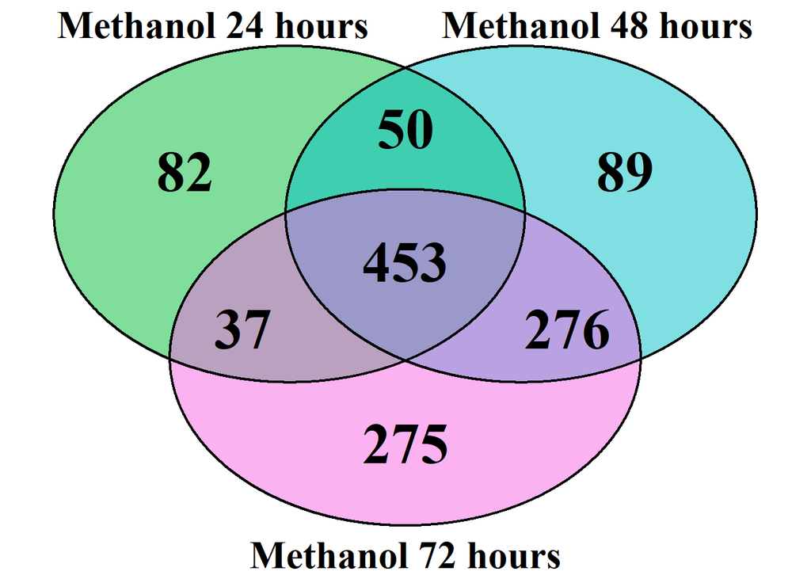

```r
# Extracting protein identifiers from each dataset
proteins_24 <- unique(significant_proteins_24$Protein)
proteins_48 <- unique(significant_proteins_48$Protein)
proteins_72 <- unique(significant_proteins_72$Protein)

# Generate a Venn diagram for the three datasets
venn.plot <- draw.triple.venn(
    area1 = length(proteins_24),
    area2 = length(proteins_48),
    area3 = length(proteins_72),
    n12 = length(intersect(proteins_24, proteins_48)),
    n23 = length(intersect(proteins_48, proteins_72)),
    n13 = length(intersect(proteins_24, proteins_72)),
    n123 = length(Reduce(intersect, list(proteins_24, proteins_48, proteins_72))),
    category = c("Methanol 24 hours", "Methanol 48 hours", "Methanol 72 hours"),
    fill = c("#00BA38", "#00BFC4", "#F564E3"),  # Use custom colors
    lty = 1,  # Set line type to 1 for solid lines
    lwd = 2,  # Set line width for circle borders
    cex = 3,  # Increase text size within the circles
    fontface = "bold",  # Make numbers inside the circles bold
    cat.cex = 2,  # Increase category text size
    cat.pos = c(-15, 15, 180),  # Adjust category label positions:
    cat.dist = 0.05,  # Adjust the distance of category labels from the center of the diagram
    cat.col = rep("black", 3),  # Set category label colors to black
    cat.fontface = "bold"  # Make category names bold
)
```

```r
# Save the Venn diagram as a PNG file
png("VennDiagram.png", width = 900, height = 900)  # Make the dimensions square
grid.draw(venn.plot)
dev.off() # Close the device after drawing
```

```r
# Print the Venn diagram
print(venn.plot)
```

[output not shown]

# Q-Q plot creation

- This compares the expected and observed p-values between the singificantly different datasets created by comparing glycerol feeding compared to the other 4 sample types.
- The function first extracts and sorts the non-missing p-values from the results, calculates their -log10 transformation, and computes the expected -log10(p-values) under a uniform distribution based on their rank. Then, it plots these observed versus expected values with ggplot2, adding a red dashed line (slope = 1) to indicate where the points would lie if the observed p-values perfectly matched the uniform expectation.

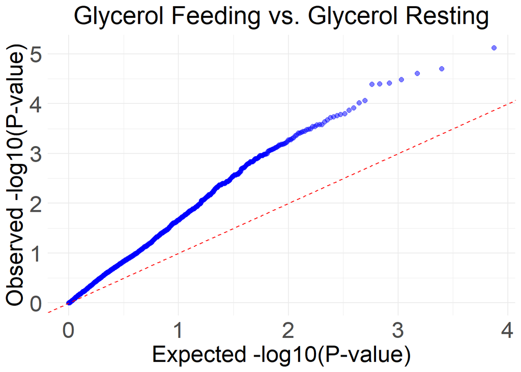

```r
# Define a theme function for reuse
custom_theme <- theme_minimal() +
  theme(
    plot.title = element_text(size = 24, hjust = 0.5),
    axis.text = element_text(size = 22),
    axis.title = element_text(size = 22)
  )

# Function to create a Q-Q plot of p-values
create_qq_plot <- function(results_df, comparison_name) {
  # Remove NA p-values
  p_values <- results_df$P.Value[!is.na(results_df$P.Value)]

  # Number of p-values
  n <- length(p_values)

  # Expected p-values under the null hypothesis (uniform distribution)
  expected_p <- (rank(p_values, ties.method = "first") - 0.5) / n

  # Create a data frame for plotting
  qq_data <- data.frame(
    Observed = -log10(sort(p_values)),
    Expected = -log10(expected_p)
  )

  # Create the Q-Q plot
  qq_plot <- ggplot(qq_data, aes(x = Expected, y = Observed)) +
    geom_point(color = "blue", alpha = 0.5, size = 2) +  # Adjust point size as needed
    geom_abline(intercept = 0, slope = 1, color = "red", linetype = "dashed") +
    labs(
      title = paste(comparison_name),
      x = "Expected -log10(P-value)",
      y = "Observed -log10(P-value)"
    ) +
    custom_theme  # Apply your custom theme here

  return(qq_plot)
}

# Generate Q-Q plots for each comparison
qq_plot_rest <- create_qq_plot(res_EB_rest$results, "Glycerol Feeding vs. Glycerol Resting")
qq_plot_24   <- create_qq_plot(res_EB_24$results, "Glycerol Feeding vs. 24 Hours Methanol Feeding")
qq_plot_48   <- create_qq_plot(res_EB_48$results, "Glycerol Feeding vs. 48 Hours Methanol Feeding")
qq_plot_72   <- create_qq_plot(res_EB_72$results, "Glycerol Feeding vs. 72 Hours Methanol Feeding")
# Print the Q-Q plots
print(qq_plot_rest)
```

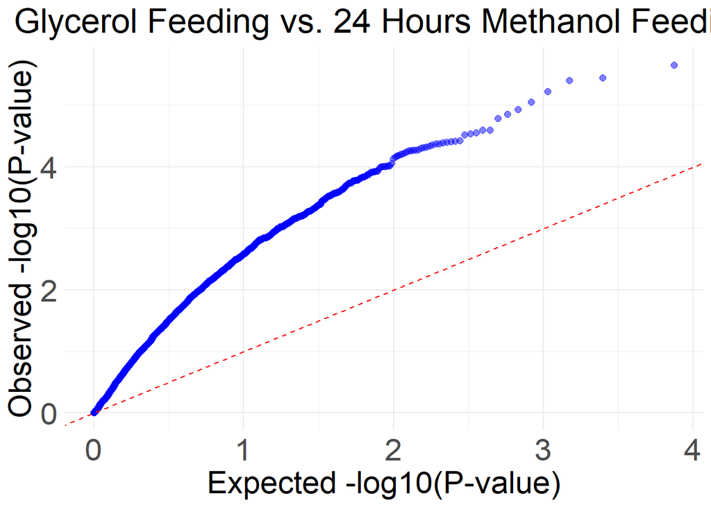

```r
print(qq_plot_24)
```

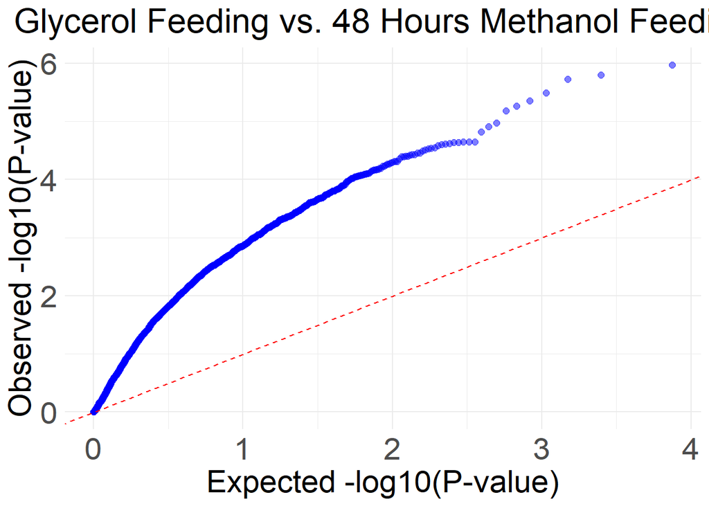

```r
print(qq_plot_48)
```

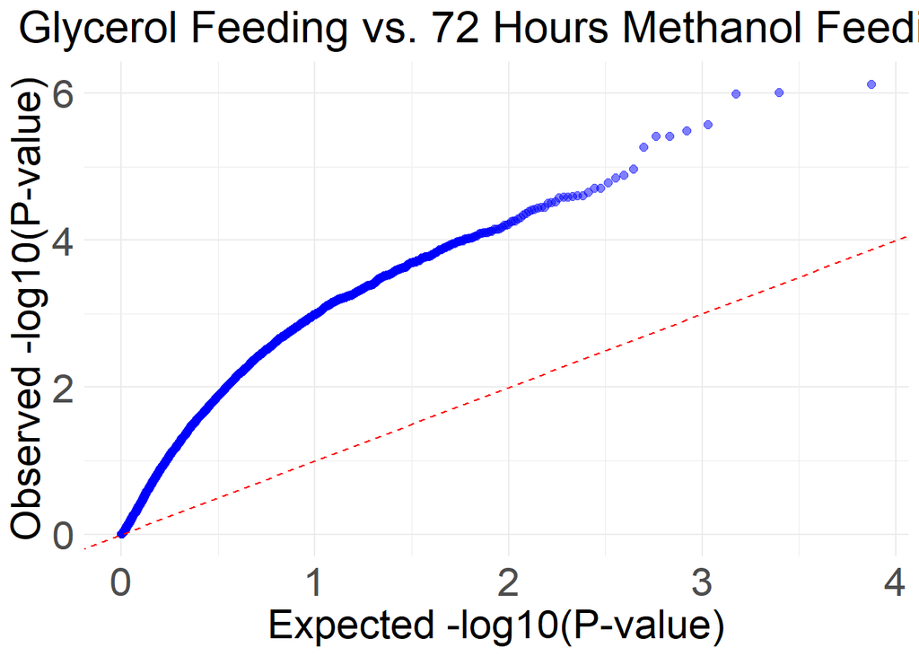

```r
print(qq_plot_72)
```

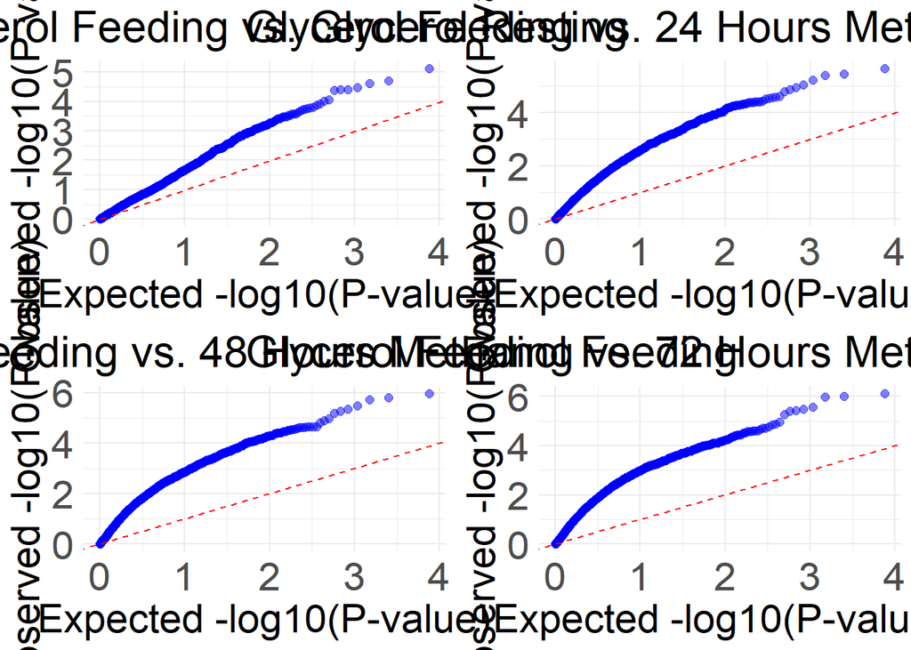

```r
# Optionally, arrange all plots together
grid.arrange(qq_plot_rest, qq_plot_24, qq_plot_48, qq_plot_72, ncol = 2)
```

# Mean-Variance plot

- Allows visual assessment of how residual variability changes with average expression levels between our sample group comparisons.
- The code first extracts the average log-expression (Amean) and computes the residual standard deviation (sdev) from the moderated limma fit (fit2) and stores them in a data frame. Then, it plots these values with ggplot2—Amean on the x-axis and sdev on the y-axis—to visualize the mean-variance trend, using a custom theme for formatting.

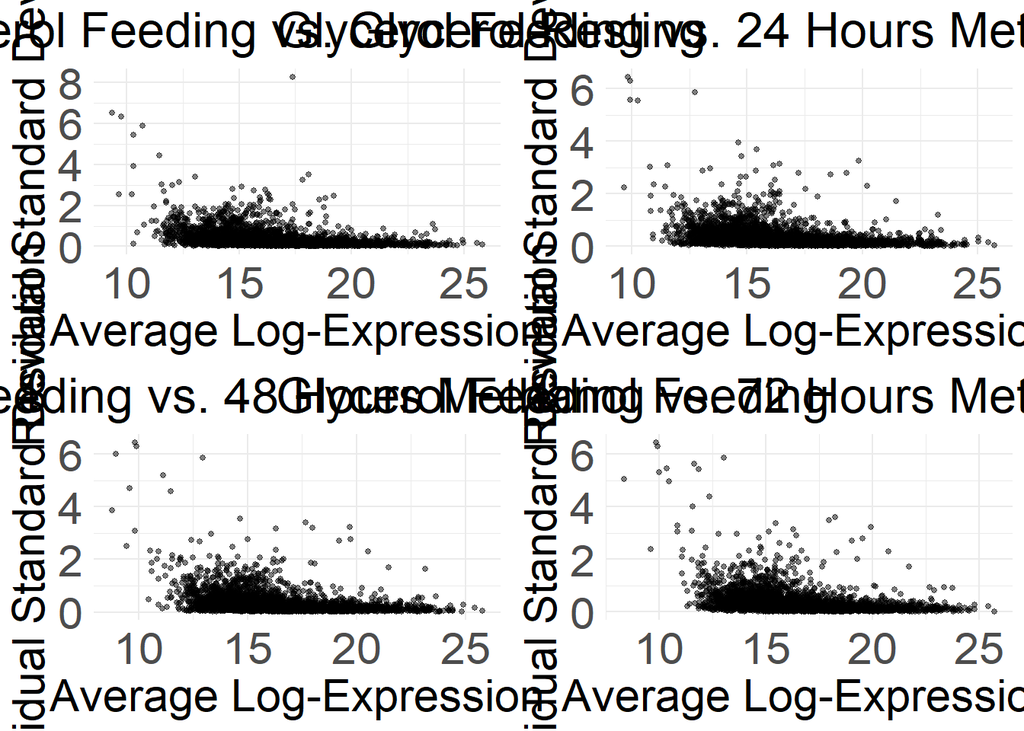

```r
# Function to extract data for plotting
extract_sa_data <- function(fit2) {
  # Residual standard deviations
  sdev <- sqrt(fit2$sigma^2)

  # Average log-expression (Amean)
  Amean <- fit2$Amean

  # Create data frame
  data.frame(Amean = Amean, sdev = sdev)
}

# Define a custom theme
custom_theme <- theme_minimal() +
  theme(
    plot.title = element_text(size = 24, hjust = 0.5),
    axis.text = element_text(size = 22),
    axis.title = element_text(size = 22)
  )

# Function to create SA plot
create_sa_plot <- function(data, comparison_name) {
  ggplot(data, aes(x = Amean, y = sdev)) +
    geom_point(alpha = 0.5, size = 1) +
    labs(
      title = comparison_name,
      x = "Average Log-Expression",
      y = "Residual Standard Deviation"
    ) +
    custom_theme
}

# Generate data frames for each fit
sa_data_rest <- extract_sa_data(res_EB_rest$fit2)
sa_plot_rest <- create_sa_plot(sa_data_rest, "Glycerol Feeding vs. Glycerol Resting")
sa_data_24 <- extract_sa_data(res_EB_24$fit2)
sa_plot_24 <- create_sa_plot(sa_data_24, "Glycerol Feeding vs. 24 Hours Methanol Feeding")
sa_data_48 <- extract_sa_data(res_EB_48$fit2)
sa_plot_48 <- create_sa_plot(sa_data_48, "Glycerol Feeding vs. 48 Hours Methanol Feeding")
sa_data_72 <- extract_sa_data(res_EB_72$fit2)
sa_plot_72 <- create_sa_plot(sa_data_72, "Glycerol Feeding vs. 72 Hours Methanol Feeding")


# Arrange the plots
grid.arrange(sa_plot_rest, sa_plot_24, sa_plot_48, sa_plot_72, ncol = 2)
```

# Prepare data for multivariate analysis

- This is to compare the groups of the data as opposed to looking at individual proteins to confirmt that there is statitical differences between the.

```r
# Map sample names: from "S1", "S2", ... to "Sample_1", "Sample_2", etc.
sample_mapping <- setNames(paste0("Sample_", 1:10), paste0("S", 1:10))
sample_info$Sample <- sample_mapping[sample_info$Sample]

# Ensure the data matrix column names match the sample names in sample_info
data_matrix <- data_imputed

# Create new names by removing the leading "S" and prepending "Sample_"
original_names <- colnames(data_matrix)  # e.g., "S10", "S1", "S2", ...
# Remove the first character ("S") and add "Sample_"
new_names <- paste0("Sample_", substring(original_names, 2))
colnames(data_matrix) <- new_names

cat("Updated data matrix column names:\n")
```

```
## Updated data matrix column names:
```

```r
print(colnames(data_matrix))
```

```
##  [1] "Sample_10" "Sample_1"  "Sample_2"  "Sample_3"  "Sample_4"  "Sample_5"
##  [7] "Sample_6"  "Sample_7"  "Sample_8"  "Sample_9"
```

```r
# Get the updated sample names from the data matrix
sample_names <- colnames(data_matrix)

# Reorder sample_info to match the order of sample_names
sample_info_ordered <- sample_info[match(sample_names, sample_info$Sample), ]

# Verify that the sample names match exactly
if (all(sample_info_ordered$Sample == sample_names)) {
  cat("Sample names match correctly!\n")
} else {
  stop("Sample names do not match. Check your data!")
}
```

```
## Sample names match correctly!
```

```r
# View the ordered sample info
cat("Ordered sample info:\n")
```

```
## Ordered sample info:
```

```r
print(sample_info_ordered)
```

```
##       Sample             Group
## 10 Sample_10 Methanol 72 hours
## 1   Sample_1  Glycerol Feeding
## 2   Sample_2  Glycerol Resting
## 3   Sample_3 Methanol 24 hours
## 4   Sample_4 Methanol 48 hours
## 5   Sample_5 Methanol 72 hours
## 6   Sample_6  Glycerol Feeding
## 7   Sample_7  Glycerol Resting
## 8   Sample_8 Methanol 24 hours
## 9   Sample_9 Methanol 48 hours
```